# CSCI E-63C: Week 4 Q&A session

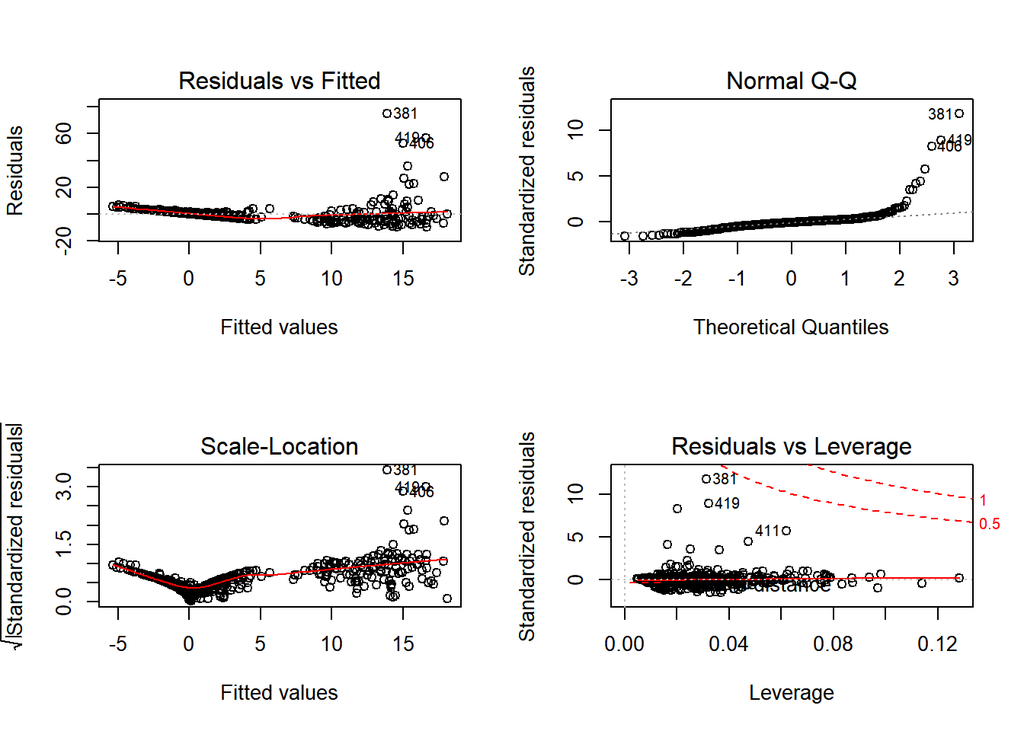

```r
old.par <- par(mfrow=c(2,2))
plot(lm(crim~.,Boston))
```

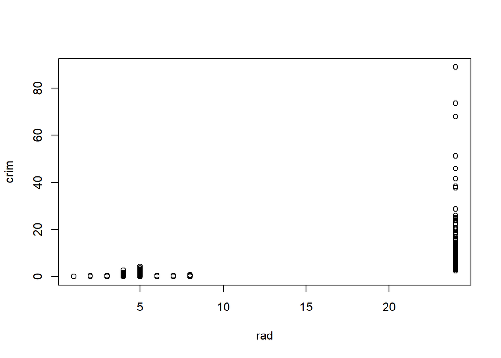

```r
par(old.par)
plot(Boston[,c("rad","crim")])
```

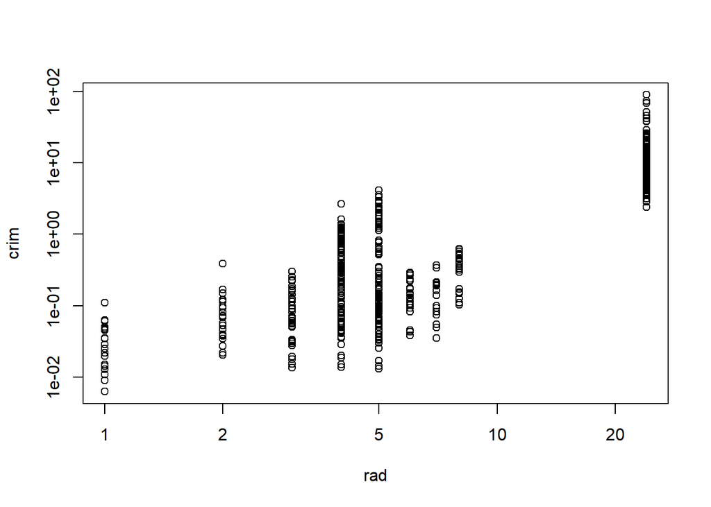

```r
plot(Boston[,c("rad","crim")],log="xy")
```

3. How do your results from (a) compare to your results from (b)? Create a plot displaying the univariate regression coefficients from (a) on the x-axis, and the multiple regression coefficients from (b) on the y-axis. That is, each predictor is displayed as a single point in the plot. Its coefficient in a simple linear regression model is shown on the x-axis, and its coefficient estimate in the multiple linear regression model is shown on the y-axis.

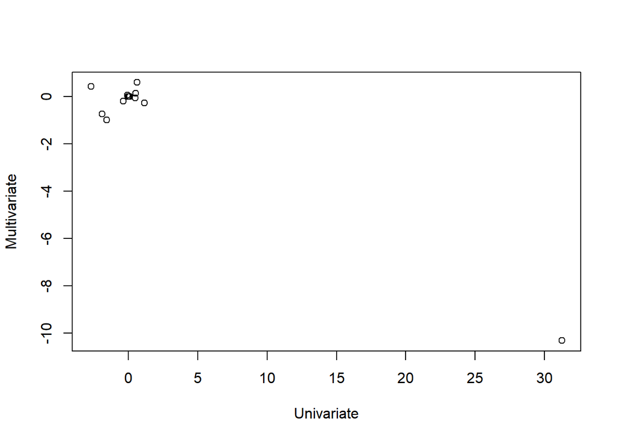

```r
plot(tmp1Dcoefs,coef(lm(crim~.,Boston))[names(tmp1Dcoefs)],xlab="Univariate",ylab="Multivariate")
```

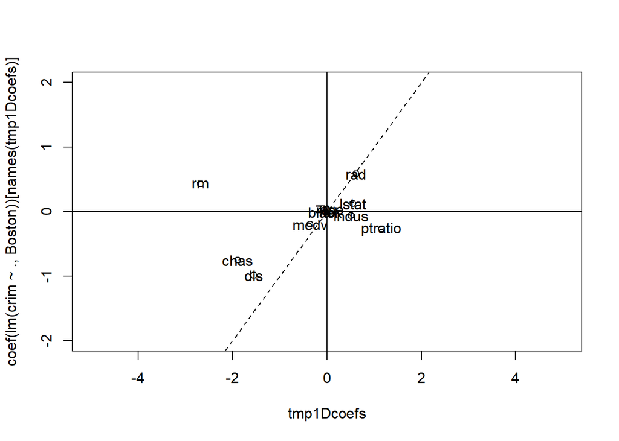

```r
plot(tmp1Dcoefs,coef(lm(crim~.,Boston))[names(tmp1Dcoefs)],ylim=c(-2,2),xlim=c(-5,5))
text(tmp1Dcoefs,coef(lm(crim~.,Boston))[names(tmp1Dcoefs)],names(tmp1Dcoefs))
abline(h=0)
abline(v=0)
abline(0,1,lty=2)
```

```
## zn
##
## Call:
## lm(formula = crim ~ ., data = tmpDat)
##
## Residuals:
##    Min     1Q Median     3Q    Max
## -4.821 -4.614 -1.294  0.473 84.130
##
## Coefficients:
##               Estimate Std. Error t value Pr(>|t|)
## (Intercept)  4.846e+00  4.330e-01  11.192  < 2e-16 ***
## zn          -3.322e-01  1.098e-01  -3.025  0.00261 **
## zn2          6.483e-03  3.861e-03   1.679  0.09375 .
## zn3         -3.776e-05  3.139e-05  -1.203  0.22954
## ---
## Signif. codes:  0 '***' 0.001 '**' 0.01 '*' 0.05 '.' 0.1 ' ' 1
##
## Residual standard error: 8.372 on 502 degrees of freedom
## Multiple R-squared:  0.05824,    Adjusted R-squared:  0.05261
## F-statistic: 10.35 on 3 and 502 DF,  p-value: 1.281e-06
```

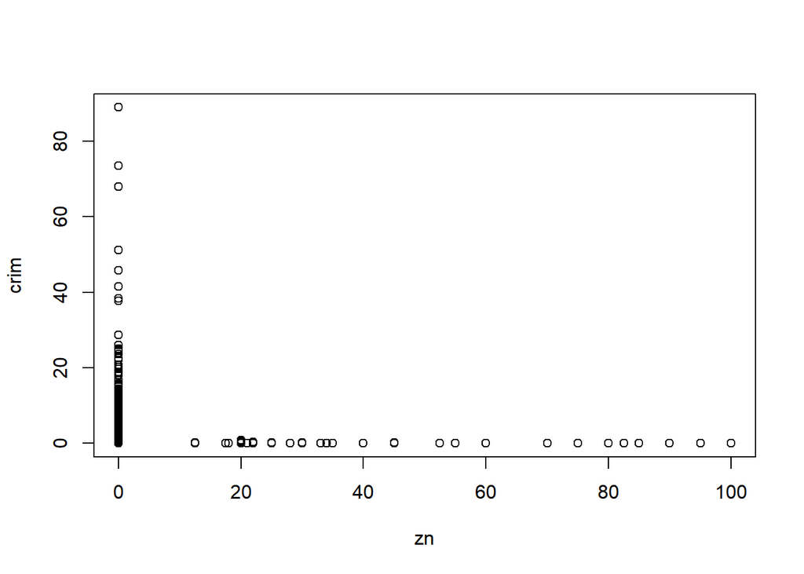

```
## indus
##
## Call:
## lm(formula = crim ~ ., data = tmpDat)
##
## Residuals:
##    Min     1Q Median     3Q    Max
## -8.278 -2.514  0.054  0.764 79.713
##
## Coefficients:
##               Estimate Std. Error t value Pr(>|t|)
## (Intercept)  3.6625683  1.5739833   2.327   0.0204 *
## indus       -1.9652129  0.4819901  -4.077 5.30e-05 ***
## indus2       0.2519373  0.0393221   6.407 3.42e-10 ***
## indus3      -0.0069760  0.0009567  -7.292 1.20e-12 ***
## ---
## Signif. codes:  0 '***' 0.001 '**' 0.01 '*' 0.05 '.' 0.1 ' ' 1
##
## Residual standard error: 7.423 on 502 degrees of freedom
## Multiple R-squared:  0.2597, Adjusted R-squared:  0.2552
## F-statistic: 58.69 on 3 and 502 DF,  p-value: < 2.2e-16
```

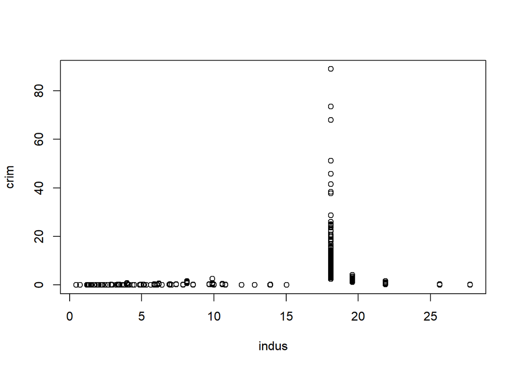

```
## chas
##
## Call:
## lm(formula = crim ~ ., data = tmpDat)
##
## Residuals:
##    Min     1Q Median     3Q    Max
## -3.738 -3.661 -3.435  0.018 85.232
##
## Coefficients: (2 not defined because of singularities)
##             Estimate Std. Error t value Pr(>|t|)
## (Intercept)   3.7444     0.3961   9.453   <2e-16 ***
## chas         -1.8928     1.5061  -1.257    0.209
## chas2             NA         NA      NA       NA
## chas3             NA         NA      NA       NA
## ---
## Signif. codes:  0 '***' 0.001 '**' 0.01 '*' 0.05 '.' 0.1 ' ' 1
##
## Residual standard error: 8.597 on 504 degrees of freedom
## Multiple R-squared:  0.003124,   Adjusted R-squared:  0.001146
## F-statistic: 1.579 on 1 and 504 DF,  p-value: 0.2094
```

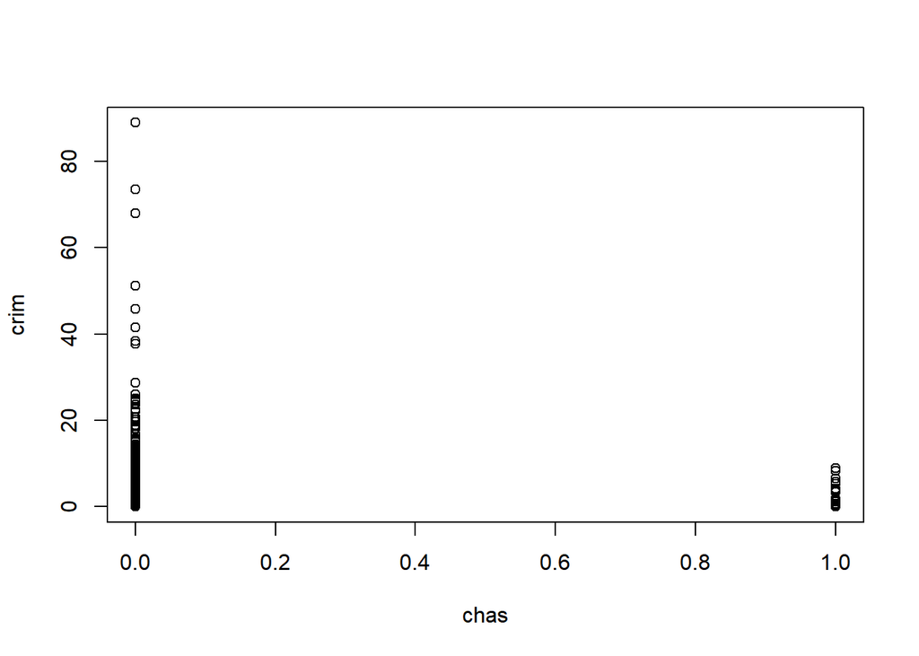

```
## nox
##
## Call:
## lm(formula = crim ~ ., data = tmpDat)
##
## Residuals:
##    Min     1Q Median     3Q    Max
## -9.110 -2.068 -0.255  0.739 78.302
##
## Coefficients:
##             Estimate Std. Error t value Pr(>|t|)
## (Intercept)   233.09      33.64   6.928 1.31e-11 ***
## nox         -1279.37     170.40  -7.508 2.76e-13 ***
## nox2         2248.54     279.90   8.033 6.81e-15 ***
## nox3        -1245.70     149.28  -8.345 6.96e-16 ***
## ---
## Signif. codes:  0 '***' 0.001 '**' 0.01 '*' 0.05 '.' 0.1 ' ' 1
##
## Residual standard error: 7.234 on 502 degrees of freedom
## Multiple R-squared:  0.297,  Adjusted R-squared:  0.2928
## F-statistic: 70.69 on 3 and 502 DF,  p-value: < 2.2e-16
```

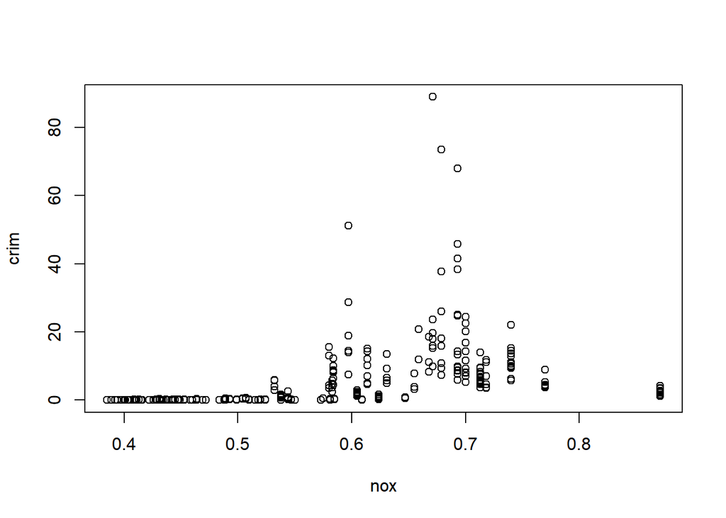

```
## rm
##
## Call:
## lm(formula = crim ~ ., data = tmpDat)
##
## Residuals:
##     Min      1Q  Median      3Q     Max
## -18.485  -3.468  -2.221  -0.015  87.219
##
## Coefficients:
##             Estimate Std. Error t value Pr(>|t|)
## (Intercept) 112.6246    64.5172   1.746   0.0815 .
## rm          -39.1501    31.3115  -1.250   0.2118
## rm2           4.5509     5.0099   0.908   0.3641
## rm3          -0.1745     0.2637  -0.662   0.5086
## ---
## Signif. codes:  0 '***' 0.001 '**' 0.01 '*' 0.05 '.' 0.1 ' ' 1
##
## Residual standard error: 8.33 on 502 degrees of freedom
## Multiple R-squared:  0.06779,    Adjusted R-squared:  0.06222
## F-statistic: 12.17 on 3 and 502 DF,  p-value: 1.067e-07
```

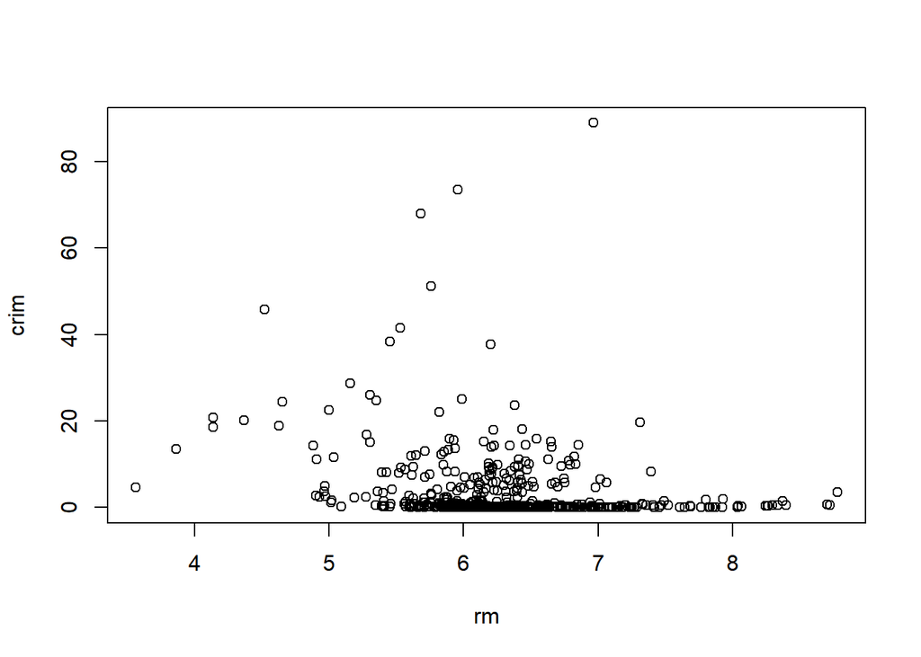

```
## age
##
## Call:
## lm(formula = crim ~ ., data = tmpDat)
##
## Residuals:
##    Min     1Q Median     3Q    Max
## -9.762 -2.673 -0.516  0.019 82.842
##
## Coefficients:
##               Estimate Std. Error t value Pr(>|t|)
## (Intercept) -2.549e+00  2.769e+00  -0.920  0.35780
## age          2.737e-01  1.864e-01   1.468  0.14266
## age2        -7.230e-03  3.637e-03  -1.988  0.04738 *
## age3         5.745e-05  2.109e-05   2.724  0.00668 **
## ---
## Signif. codes:  0 '***' 0.001 '**' 0.01 '*' 0.05 '.' 0.1 ' ' 1
##
## Residual standard error: 7.84 on 502 degrees of freedom
## Multiple R-squared:  0.1742, Adjusted R-squared:  0.1693
## F-statistic: 35.31 on 3 and 502 DF,  p-value: < 2.2e-16
```

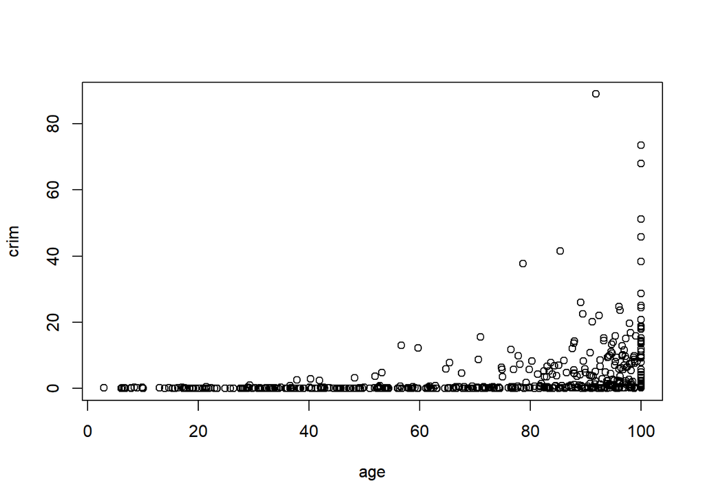

```
## dis
##
## Call:
## lm(formula = crim ~ ., data = tmpDat)
##
## Residuals:
##     Min      1Q  Median      3Q     Max
## -10.757  -2.588   0.031   1.267  76.378
##
## Coefficients:
##             Estimate Std. Error t value Pr(>|t|)
## (Intercept)  30.0476     2.4459  12.285  < 2e-16 ***
## dis         -15.5543     1.7360  -8.960  < 2e-16 ***
## dis2          2.4521     0.3464   7.078 4.94e-12 ***
## dis3         -0.1186     0.0204  -5.814 1.09e-08 ***
## ---
## Signif. codes:  0 '***' 0.001 '**' 0.01 '*' 0.05 '.' 0.1 ' ' 1
##
## Residual standard error: 7.331 on 502 degrees of freedom
## Multiple R-squared:  0.2778, Adjusted R-squared:  0.2735
## F-statistic: 64.37 on 3 and 502 DF,  p-value: < 2.2e-16
```

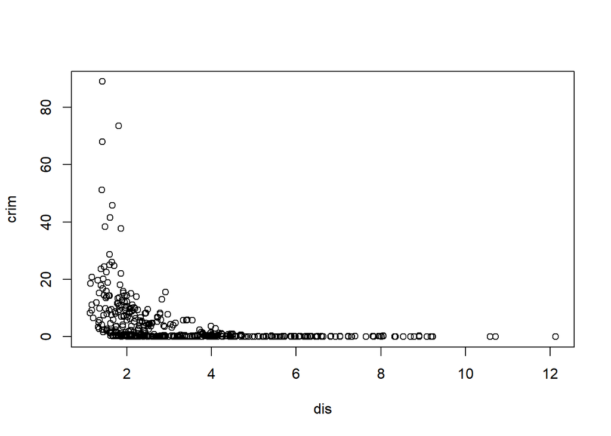

```
## rad
##
## Call:
## lm(formula = crim ~ ., data = tmpDat)
##
## Residuals:
##     Min      1Q  Median      3Q     Max
## -10.381  -0.412  -0.269   0.179  76.217
##
## Coefficients:
##              Estimate Std. Error t value Pr(>|t|)
## (Intercept) -0.605545   2.050108  -0.295    0.768
## rad          0.512736   1.043597   0.491    0.623
## rad2        -0.075177   0.148543  -0.506    0.613
## rad3         0.003209   0.004564   0.703    0.482
##
## Residual standard error: 6.682 on 502 degrees of freedom
## Multiple R-squared:    0.4,  Adjusted R-squared:  0.3965
## F-statistic: 111.6 on 3 and 502 DF,  p-value: < 2.2e-16
```

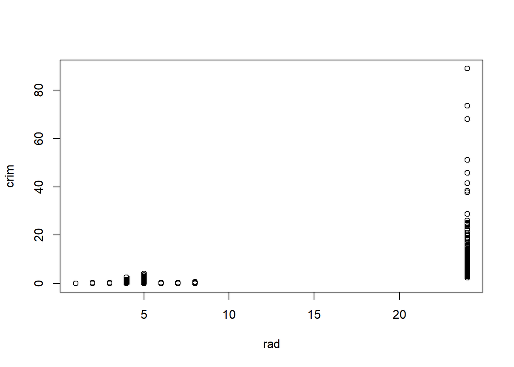

```
## tax
##
## Call:
## lm(formula = crim ~ ., data = tmpDat)
##
## Residuals:
##     Min      1Q  Median      3Q     Max
## -13.273  -1.389   0.046   0.536  76.950
##
## Coefficients:
##               Estimate Std. Error t value Pr(>|t|)
## (Intercept)  1.918e+01  1.180e+01   1.626    0.105
## tax         -1.533e-01  9.568e-02  -1.602    0.110
## tax2         3.608e-04  2.425e-04   1.488    0.137
## tax3        -2.204e-07  1.889e-07  -1.167    0.244
##
## Residual standard error: 6.854 on 502 degrees of freedom
## Multiple R-squared:  0.3689, Adjusted R-squared:  0.3651
## F-statistic:  97.8 on 3 and 502 DF,  p-value: < 2.2e-16
```

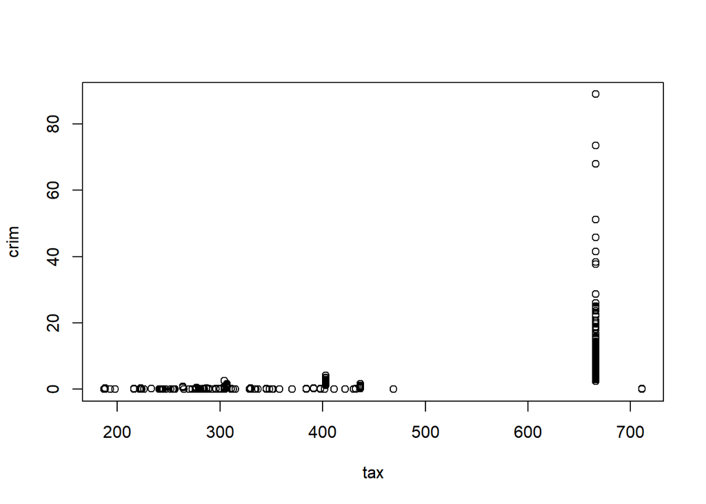

```
## ptratio
##
## Call:
## lm(formula = crim ~ ., data = tmpDat)
##
## Residuals:
##    Min     1Q Median     3Q    Max
## -6.833 -4.146 -1.655  1.408 82.697
##
## Coefficients:
##              Estimate Std. Error t value Pr(>|t|)
## (Intercept) 477.18405  156.79498   3.043  0.00246 **
## ptratio     -82.36054   27.64394  -2.979  0.00303 **
## ptratio2      4.63535    1.60832   2.882  0.00412 **
## ptratio3     -0.08476    0.03090  -2.743  0.00630 **
## ---
## Signif. codes:  0 '***' 0.001 '**' 0.01 '*' 0.05 '.' 0.1 ' ' 1
##
## Residual standard error: 8.122 on 502 degrees of freedom
## Multiple R-squared:  0.1138, Adjusted R-squared:  0.1085
## F-statistic: 21.48 on 3 and 502 DF,  p-value: 4.171e-13
```

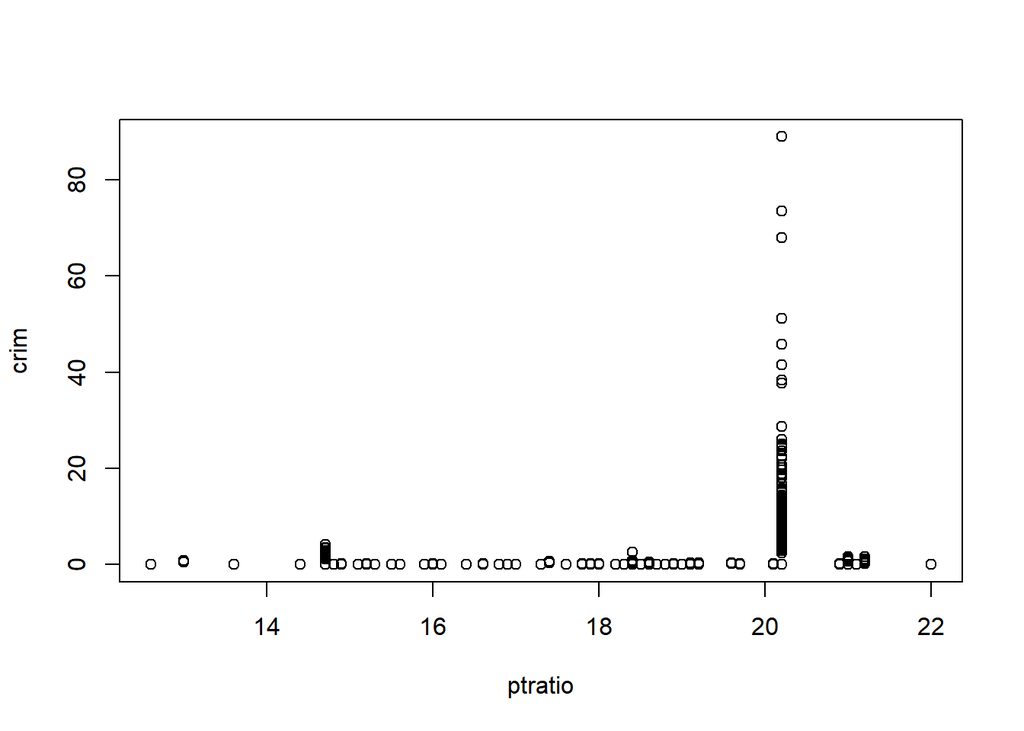

```
## black
##
## Call:
## lm(formula = crim ~ ., data = tmpDat)
##
## Residuals:
##     Min      1Q  Median      3Q     Max
## -13.096  -2.343  -2.128  -1.439  86.790
##
## Coefficients:
##               Estimate Std. Error t value Pr(>|t|)
## (Intercept)  1.826e+01  2.305e+00   7.924  1.5e-14 ***
## black       -8.356e-02  5.633e-02  -1.483    0.139
## black2       2.137e-04  2.984e-04   0.716    0.474
## black3      -2.652e-07  4.364e-07  -0.608    0.544
## ---
## Signif. codes:  0 '***' 0.001 '**' 0.01 '*' 0.05 '.' 0.1 ' ' 1
##
## Residual standard error: 7.955 on 502 degrees of freedom
## Multiple R-squared:  0.1498, Adjusted R-squared:  0.1448
## F-statistic: 29.49 on 3 and 502 DF,  p-value: < 2.2e-16
```

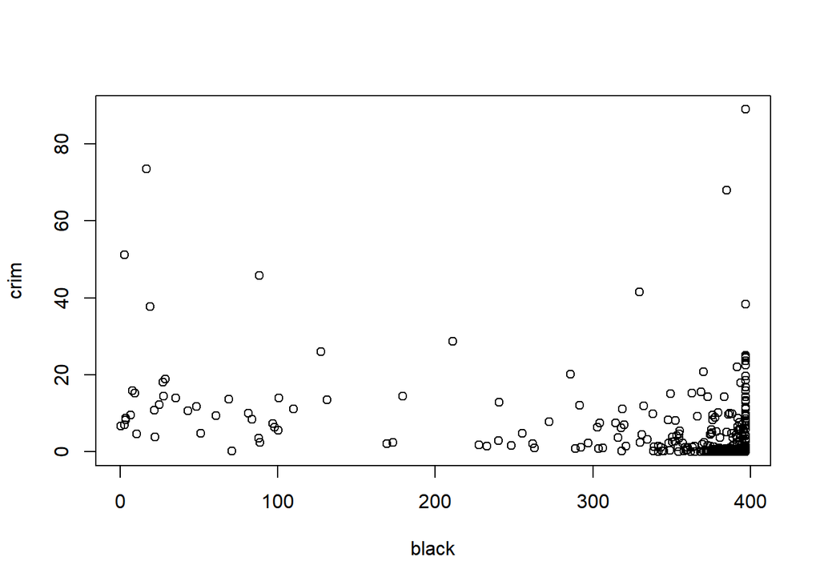

```
## lstat
##
## Call:
## lm(formula = crim ~ ., data = tmpDat)
##
## Residuals:
##     Min      1Q  Median      3Q     Max
## -15.234  -2.151  -0.486   0.066  83.353
##
## Coefficients:
##               Estimate Std. Error t value Pr(>|t|)
## (Intercept)  1.2009656  2.0286452   0.592   0.5541
## lstat       -0.4490656  0.4648911  -0.966   0.3345
## lstat2       0.0557794  0.0301156   1.852   0.0646 .
## lstat3      -0.0008574  0.0005652  -1.517   0.1299
## ---
## Signif. codes:  0 '***' 0.001 '**' 0.01 '*' 0.05 '.' 0.1 ' ' 1
##
## Residual standard error: 7.629 on 502 degrees of freedom
## Multiple R-squared:  0.2179, Adjusted R-squared:  0.2133
## F-statistic: 46.63 on 3 and 502 DF,  p-value: < 2.2e-16
```

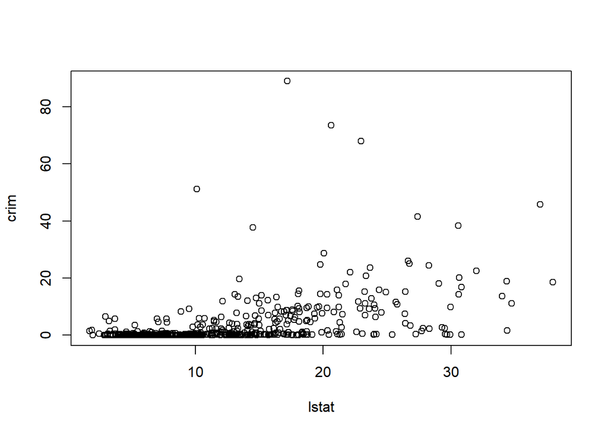

```
## medv
##
## Call:
## lm(formula = crim ~ ., data = tmpDat)
##
## Residuals:
##     Min      1Q  Median      3Q     Max
## -24.427  -1.976  -0.437   0.439  73.655
##
## Coefficients:
##               Estimate Std. Error t value Pr(>|t|)
## (Intercept) 53.1655381  3.3563105  15.840  < 2e-16 ***
## medv        -5.0948305  0.4338321 -11.744  < 2e-16 ***
## medv2        0.1554965  0.0171904   9.046  < 2e-16 ***
## medv3       -0.0014901  0.0002038  -7.312 1.05e-12 ***
## ---
## Signif. codes:  0 '***' 0.001 '**' 0.01 '*' 0.05 '.' 0.1 ' ' 1
##
## Residual standard error: 6.569 on 502 degrees of freedom
## Multiple R-squared:  0.4202, Adjusted R-squared:  0.4167
## F-statistic: 121.3 on 3 and 502 DF,  p-value: < 2.2e-16
```

[1 more figures not shown]

```r
# non-linear fits:
for ( iTmp in 2:dim(Boston)[2] ) {
  cat(colnames(Boston)[iTmp],fill=TRUE)
  tmpDat <- Boston[,c(1,iTmp)]
  tmpDat <- cbind(tmpDat,tmpDat[,2]^2,tmpDat[,2]^3)
  colnames(tmpDat) <- c("crim",paste0(colnames(Boston)[iTmp],c("","2","3")))
  lmTmp <- lm(crim~.,tmpDat)
  print(summary(lmTmp))
  plot(Boston[,c(iTmp,1)])
}
```

## Ch.5.4, Exercise 9

We will now consider the `Boston` housing data set, from the `MASS` library.

1. Based on this data set, provide an estimate for the population mean of `medv`. Call this estimate $\hat{\mu}$.

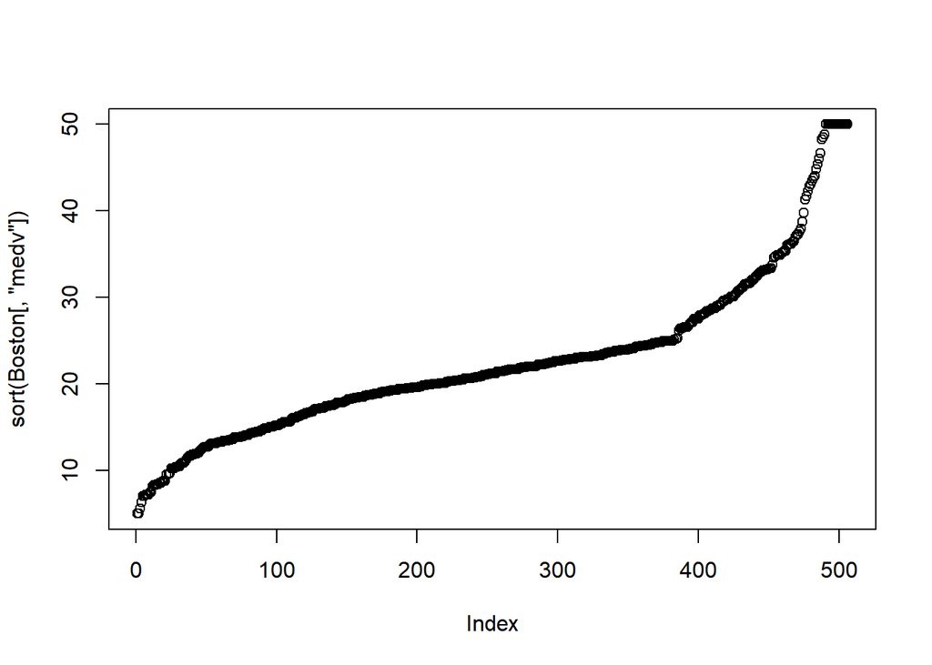

```r
plot(sort(Boston[,"medv"]))
```

```r
mean(Boston[,"medv"])
```

```
## [1] 22.53281
```

2. Provide an estimate of the standard error of $\hat{\mu}$. Interpret this result.

*Hint: We can compute the standard error of the sample mean by dividing the sample standard deviation by the square root of the number of observations.*

```r
sd(Boston[,"medv"]) / sqrt(nrow(Boston))
```

```
## [1] 0.4088611
```

3. Now estimate the standard error of $\hat{\mu}$ using the bootstrap. How does this compare to your answer from (b)?

```r
library(boot)
boot(Boston,function(x,i)mean(x[i,"medv"]),1000)
```

```
##
## ORDINARY NONPARAMETRIC BOOTSTRAP
##
##
## Call:
## boot(data = Boston, statistic = function(x, i) mean(x[i, "medv"]),
##     R = 1000)
##
##
## Bootstrap Statistics :
##     original      bias    std. error
## t1* 22.53281 0.008186957   0.4100113
```

4. Based on your bootstrap estimate from (c), provide a 95% confidence interval for the mean of medv. Compare it to the results obtained using `t.test(Boston$medv)`.

*Hint: You can approximate a 95% confidence interval using the formula $\left[\hat{\mu}-2SE(\hat{\mu}), \hat{\mu}+2SE(\hat{\mu})\right]$.

```r
boot.ci(boot(Boston,function(x,i)mean(x[i,"medv"]),1000))
```

```
## BOOTSTRAP CONFIDENCE INTERVAL CALCULATIONS
## Based on 1000 bootstrap replicates
##
## CALL :
## boot.ci(boot.out = boot(Boston, function(x, i) mean(x[i, "medv"]),
##     1000))
##
## Intervals :
## Level      Normal              Basic
## 95%   (21.77, 23.35 )   (21.71, 23.34 )
##
## Level     Percentile            BCa
## 95%   (21.72, 23.36 )   (21.84, 23.44 )
## Calculations and Intervals on Original Scale
```

```r
t.test(Boston[,"medv"])$conf.int
```

```
## [1] 21.72953 23.33608
## attr(,"conf.level")
## [1] 0.95
```

5. Based on this data set, provide an estimate, $\hat{\mu}_{med}$, for the median value of `medv` in the population.

```r
median(Boston[,"medv"])
```

```
## [1] 21.2
```

6. We now would like to estimate the standard error of $\hat{\mu}_{med}$. Unfortunately, there is no simple formula for computing the standard error of the median. Instead, estimate the standard error of the median using the bootstrap. Comment on your findings.

```r
boot(Boston,function(x,i)median(x[i,"medv"]),1000)
```

```
##
## ORDINARY NONPARAMETRIC BOOTSTRAP
##
##
## Call:
## boot(data = Boston, statistic = function(x, i) median(x[i, "medv"]),
##     R = 1000)
##
##
## Bootstrap Statistics :
##     original  bias    std. error
## t1*     21.2 -0.0055   0.3682123
```

```r
boot.ci(boot(Boston,function(x,i)median(x[i,"medv"]),1000))
```

```
## BOOTSTRAP CONFIDENCE INTERVAL CALCULATIONS
## Based on 1000 bootstrap replicates
##
## CALL :
## boot.ci(boot.out = boot(Boston, function(x, i) median(x[i, "medv"]),
##     1000))
##
## Intervals :
## Level      Normal              Basic
## 95%   (20.46, 21.96 )   (20.55, 21.95 )
##
## Level     Percentile            BCa
## 95%   (20.45, 21.85 )   (20.40, 21.70 )
## Calculations and Intervals on Original Scale
```

7. Based on this data set, provide an estimate for the tenth percentile of `medv` in Boston suburbs. Call this quantity $\hat{\mu}_{0.1}$. (You can use the `quantile()` function.)

```r
quantile(Boston[,"medv"],prob=0.1)
```

```
##   10%
## 12.75
```

8. Use the bootstrap to estimate the standard error of $\hat{\mu}_{0.1}$. Comment on your findings.

```r
boot(Boston,function(x,i)quantile(x[i,"medv"],prob=0.1),1000)
```

```
##
## ORDINARY NONPARAMETRIC BOOTSTRAP
##
##
## Call:
## boot(data = Boston, statistic = function(x, i) quantile(x[i,
##     "medv"], prob = 0.1), R = 1000)
##
##
## Bootstrap Statistics :
##     original  bias    std. error
## t1*    12.75 0.01635   0.5073782
```

```r
boot.ci(boot(Boston,function(x,i)quantile(x[i,"medv"],prob=0.1),1000))
```

```
## BOOTSTRAP CONFIDENCE INTERVAL CALCULATIONS
## Based on 1000 bootstrap replicates
##
## CALL :
## boot.ci(boot.out = boot(Boston, function(x, i) quantile(x[i,
##     "medv"], prob = 0.1), 1000))
##
## Intervals :
## Level      Normal              Basic
## 95%   (11.76, 13.73 )   (12.00, 13.75 )
##
## Level     Percentile            BCa
## 95%   (11.75, 13.50 )   (11.60, 13.40 )
## Calculations and Intervals on Original Scale
```